# Análisis Probabilidad y Estadística Computacional

Kamila Castillo Montes

2026-09-03

# 1. ¿De qué trata este análisis?

En el trabajo diario de un equipo de software y DevOps, monitorear el tiempo que tarda un cambio desde que se escribe hasta que llega a producción (*Lead Time for Changes*) es clave para entender si los procesos son ágiles o si hay cuellos de botella.

En este informe asumo el rol de analista para examinar un histórico simulado de 5.000 eventos de despliegue. El objetivo es responder preguntas prácticas de ingeniería con respaldo numérico: ¿cuánto tarda normalmente un pase a producción?, ¿qué equipos o módulos concentran más demoras?, y ¿los cambios más grandes realmente provocan más bugs o fallas en el sistema?

# 2. Preparación y Depuración del Dataset

Para reflejar un escenario real de operaciones, el conjunto de datos no viene perfectamente limpio: combina cambios rápidos con entregas mayores, arrastra registros repetidos por fallos de timeout y presenta casos extremos de tareas bloqueadas.

Además, se acota la métrica a valores estrictamente no negativos (las horas de trabajo no pueden ser menores a cero) y se vincula el tamaño del cambio con la probabilidad de registrar bugs y fallas en el despliegue.

```r
if (!requireNamespace("moments", quietly = TRUE)) install.packages("moments")
if (!requireNamespace("dplyr", quietly = TRUE)) install.packages("dplyr")

library(moments)
library(dplyr)

set.seed(2026)
n <- 5000

# 1. Simulación bimodal: cambios rápidos (~4 hrs) vs. desarrollos mayores (~48 hrs)
n1 <- round(n * 0.58)
modo_rapido <- rgamma(n1, shape = 2.3, scale = 1.8)

n2 <- round(n * 0.38)
modo_lento <- rlnorm(n2, meanlog = log(48), sdlog = 0.38)

n3 <- n - n1 - n2
outliers_extremos <- runif(n3, min = 140, max = 320)

horas_raw <- sample(c(modo_rapido, modo_lento, outliers_extremos))

# Datos no limpios: mezcla de enteros y números reales
horas_raw <- ifelse(runif(n) > 0.50, round(horas_raw), round(horas_raw, 2))

# Introducir valores duplicados sistemáticos por timeouts fijos
indices_duplicados <- sample(1:n, size = 160)
horas_raw[indices_duplicados] <- rep(c(24, 48, 72), length.out = 160)

# Restricción física: horas >= 0
horas_raw <- pmax(horas_raw, 0)

# Variables categóricas
equipos     <- sample(c("Alpha", "Beta", "Gamma", "Delta"), size = n, replace = TRUE,
                      prob = c(0.28, 0.26, 0.24, 0.22))
modulos     <- sample(c("Auth-Service", "Billing", "Frontend-UI", "Core-API", "Database"),
                      size = n, replace = TRUE)
prioridades <- sample(c("Baja", "Media", "Alta", "Crítica"), size = n, replace = TRUE,
                      prob = c(0.20, 0.45, 0.25, 0.10))

# Dataframe consolidado
df_devops <- data.frame(
  commit_id       = paste0("PR-", 10001:(10000 + n)),
  equipo          = equipos,
  modulo          = modulos,
  prioridad       = prioridades,
  lead_time_horas = horas_raw,
  stringsAsFactors = FALSE
)

# Variable complementaria: Líneas de Código (LoC)
df_devops$lineas_cambiadas <- round(
  pmax(10, (df_devops$lead_time_horas * 12) + rnorm(n, mean = 50, sd = 120))
)

# Variables de estabilidad: Bugs y Estado del Despliegue
df_devops$num_bugs <- rpois(n, lambda = pmax(0.2, df_devops$lineas_cambiadas / 250))

prob_fallo <- pmin(0.65, 0.04 + (df_devops$num_bugs * 0.08) + (df_devops$lead_time_horas / 600))
df_devops$deploy_status <- sapply(prob_fallo, function(p) {
  sample(c("success", "failed", "rolled_back"), size = 1, prob = c(1 - p, p * 0.7, p * 0.3))
})

# Exportación del archivo físico exigido por la pauta
write.csv(df_devops, "devops_metrics.csv", row.names = FALSE)
```

# 3. ¿Cómo se comportan los tiempos de entrega?

## 3.1 Valores centrales y el problema de los casos atípicos

Cuando miramos los datos brutos, la media aritmética sube drásticamente debido a un puñado de incidentes críticos que quedaron estancados por días.

Para ver el impacto real de estas distorsiones, comparamos las métricas globales contra un filtrado usando el criterio del Rango Intercuartílico (IQR de Tukey), que corta las colas excesivas:

```r
lead_times <- df_devops$lead_time_horas

calcular_moda <- function(x) {
  tabla_frec <- table(round(x, 1))
  as.numeric(names(tabla_frec[tabla_frec == max(tabla_frec)]))[1]
}

# Medidas globales
media_global     <- mean(lead_times)
mediana_global   <- median(lead_times)
moda_global      <- calcular_moda(lead_times)
desv_std_global  <- sd(lead_times)
asimetria_global <- moments::skewness(lead_times)
curtosis_global  <- moments::kurtosis(lead_times)

# Vallas de Tukey
q1 <- quantile(lead_times, 0.25)
q3 <- quantile(lead_times, 0.75)
iqr_val <- IQR(lead_times)
umbral_superior <- q3 + 1.5 * iqr_val

lead_times_limpios <- lead_times[lead_times <= umbral_superior]

# Medidas sin valores atípicos
media_iqr     <- mean(lead_times_limpios)
mediana_iqr   <- median(lead_times_limpios)
moda_iqr      <- calcular_moda(lead_times_limpios)
desv_std_iqr  <- sd(lead_times_limpios)
asimetria_iqr <- moments::skewness(lead_times_limpios)
curtosis_iqr  <- moments::kurtosis(lead_times_limpios)

tabla_comparativa <- data.frame(
  Metrica = c("Media (Horas)", "Mediana (Horas)", "Moda Principal (Horas)",
              "Desviación Estándar (Horas)", "Coeficiente Asimetría", "Curtosis"),
  Muestra_Completa = round(c(media_global, mediana_global, moda_global,
                             desv_std_global, asimetria_global, curtosis_global), 2),
  Sin_Atipicos_IQR = round(c(media_iqr, mediana_iqr, moda_iqr,
                           desv_std_iqr, asimetria_iqr, curtosis_iqr), 2)
)

knitr::kable(tabla_comparativa, caption = "Contraste univariado: Antes y después de filtrar valores atípicos")
```

Contraste univariado: Antes y después de filtrar valores atípicos

| Metrica | Muestra_Completa | Sin_Atipicos_IQR |
| --- | --- | --- |
| Media (Horas) | 31.91 | 23.15 |
| Mediana (Horas) | 7.66 | 7.00 |
| Moda Principal (Horas) | 2.00 | 2.00 |
| Desviación Estándar (Horas) | 49.20 | 25.75 |
| Coeficiente Asimetría | 3.17 | 1.02 |
| Curtosis | 15.16 | 2.94 |

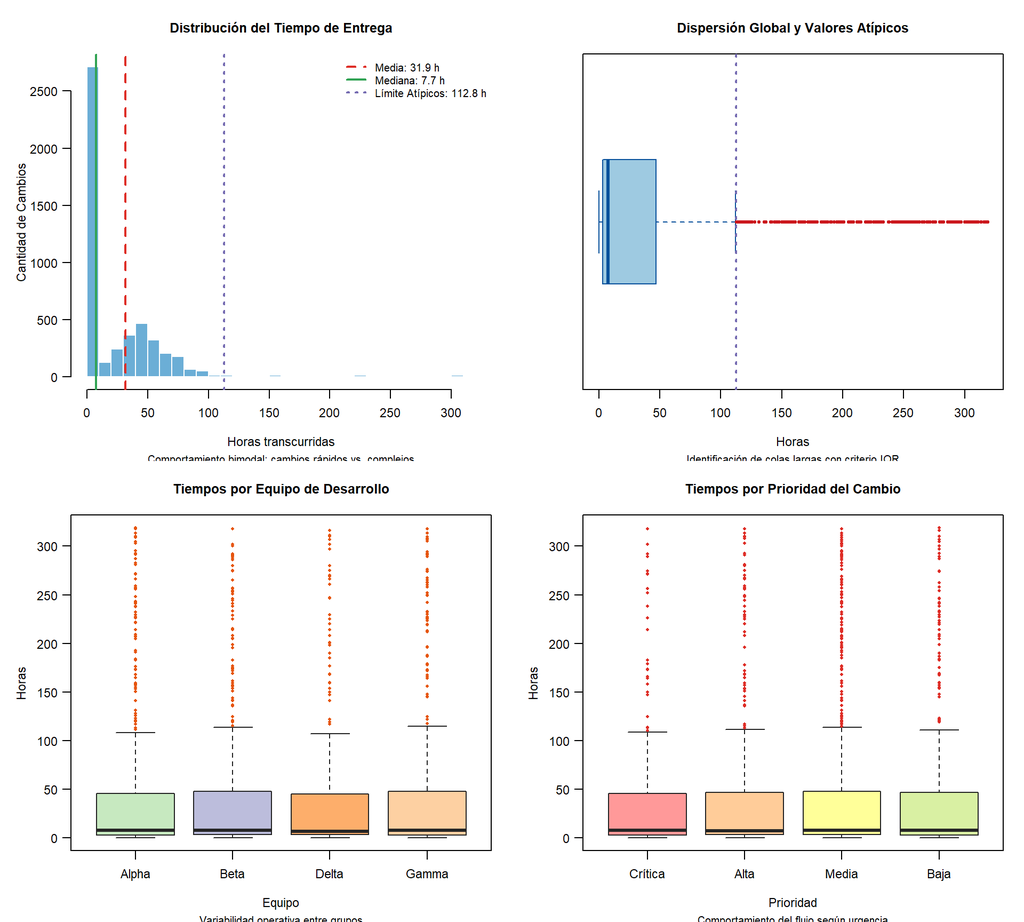

```r
# 1. Configurar panel 2x2 con márgenes adecuados
par(mfrow = c(2, 2), mar = c(4.2, 4.2, 3.2, 1.2), mgp = c(2.5, 0.8, 0))

# --- Gráfico 1: Histograma Global ---
hist(df_devops$lead_time_horas,
     breaks = 40,
     col = "#6baed6",
     border = "white",
     main = "Distribución del Tiempo de Entrega",
     sub  = "Comportamiento bimodal: cambios rápidos vs. complejos",
     xlab = "Horas transcurridas",
     ylab = "Cantidad de Cambios",
     las = 1, cex.main = 0.95, cex.sub = 0.75, cex.axis = 0.85, cex.lab = 0.85)

abline(v = media_global, col = "#de2d26", lwd = 2, lty = 2)
abline(v = mediana_global, col = "#31a354", lwd = 2, lty = 1)
abline(v = umbral_superior, col = "#756bb1", lwd = 2, lty = 3)

legend("topright",
       legend = c(paste("Media:", round(media_global, 1), "h"),
                  paste("Mediana:", round(mediana_global, 1), "h"),
                  paste("Límite Atípicos:", round(umbral_superior, 1), "h")),
       col = c("#de2d26", "#31a354", "#756bb1"),
       lty = c(2, 1, 3), lwd = 2, bty = "n", cex = 0.75)

# --- Gráfico 2: Diagrama de Caja Global ---
boxplot(df_devops$lead_time_horas,
        horizontal = TRUE,
        col = "#9ecae1",
        border = "#08519c",
        main = "Dispersión Global y Valores Atípicos",
        sub  = "Identificación de colas largas con criterio IQR",
        xlab = "Horas",
        las = 1, cex.main = 0.95, cex.sub = 0.75, cex.axis = 0.85, cex.lab = 0.85,
        outcol = "#cb181d", pch = 19, cex = 0.5)

abline(v = umbral_superior, col = "#756bb1", lwd = 2, lty = 3)

# --- Gráfico 3: Diagrama de Caja por Equipo ---
boxplot(lead_time_horas ~ equipo,
        data = df_devops,
        col = c("#c7e9c0", "#bcbddc", "#fdae6b", "#fdd0a2"),
        border = "#252525",
        main = "Tiempos por Equipo de Desarrollo",
        sub  = "Variabilidad operativa entre grupos",
        xlab = "Equipo",
        ylab = "Horas",
        las = 1, cex.main = 0.95, cex.sub = 0.75, cex.axis = 0.85, cex.lab = 0.85,
        outcol = "#e6550d", pch = 16, cex = 0.5)

# --- Gráfico 4: Diagrama de Caja por Prioridad ---
df_devops$prioridad_factor <- factor(df_devops$prioridad,
                                     levels = c("Crítica", "Alta", "Media", "Baja"))

boxplot(lead_time_horas ~ prioridad_factor,
        data = df_devops,
        col = c("#ff9999", "#ffcc99", "#ffff99", "#d9f0a3"),
        border = "#252525",
        main = "Tiempos por Prioridad del Cambio",
        sub  = "Comportamiento del flujo según urgencia",
        xlab = "Prioridad",
        ylab = "Horas",
        las = 1, cex.main = 0.95, cex.sub = 0.75, cex.axis = 0.85, cex.lab = 0.85,
        outcol = "#de2d26", pch = 16, cex = 0.5)
```